# Visualization 2

# Setup

Include a few other figure preferences in global options declared at the outset of each .Rmd file (this code chunk just gets copy-and-pasted to the beginning of every new file).

```r
library(tidyverse)
```

```r
library(ggridges)
library(patchwork)

knitr::opts_chunk$set(
  fig.width = 6,
  fig.asp = .6,
  out.width = "90%"
)

theme_set(theme_minimal() + theme(legend.position = "bottom"))

options(
  ggplot2.continuous.colour = "viridis",
  ggplot2.continuous.fill = "viridis"
)

scale_colour_discrete = scale_colour_viridis_d
scale_fill_discrete = scale_fill_viridis_d
```

We’ll be working with NOAA weather data, which is downloaded using `rnoaa::meteo_pull_monitors` function in the code chunk below; similar code underlies the weather dataset used elsewhere in the course. Because this process can take some time, I’ll cache the code chunk.

```r
weather_df =
  rnoaa::meteo_pull_monitors(
    c("USW00094728", "USW00022534", "USS0023B17S"),
    var = c("PRCP", "TMIN", "TMAX"),
    date_min = "2021-01-01",
    date_max = "2022-12-31") |>
  mutate(
    name = recode(
      id,
      USW00094728 = "CentralPark_NY",
      USW00022534 = "Molokai_HI",
      USS0023B17S = "Waterhole_WA"),
    tmin = tmin / 10,
    tmax = tmax / 10) |>
  select(name, id, everything())
```

[output not shown]

[output not shown]

[output not shown]

[output not shown]

[output not shown]

[output not shown]

[output not shown]

[output not shown]

[output not shown]

```r
# can use weather_df |> view() in the command line to see the full dataset
```

# Same Plot From Last Time

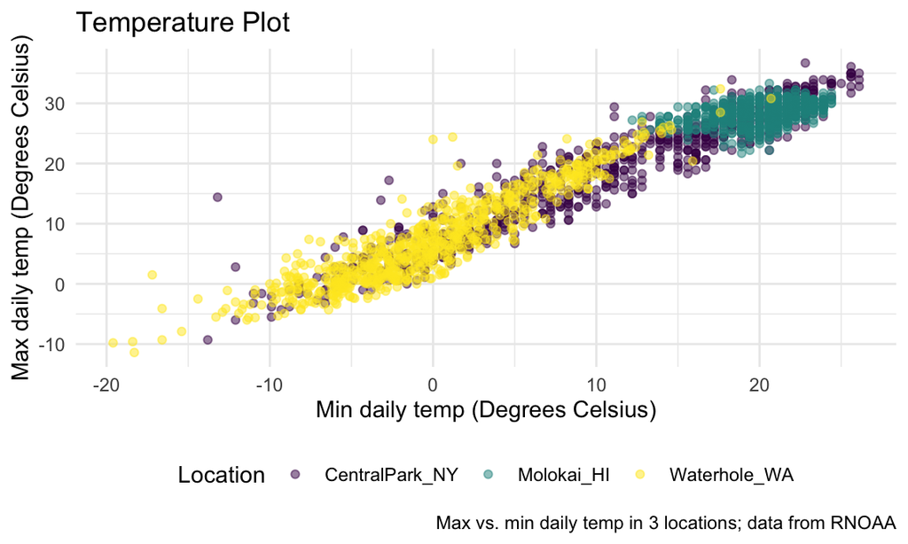

```r
weather_df |>
  ggplot(aes(x = tmin, y = tmax, color = name)) +
  geom_point(alpha = .5) +
  labs(
    title = "Temperature Plot",
    x = "Min daily temp (Degrees Celsius)",
    y = "Max daily temp (Degrees Celsius)",
    color = "Location",
    caption = "Max vs. min daily temp in 3 locations; data from RNOAA"
  )
```

# Adding Scales

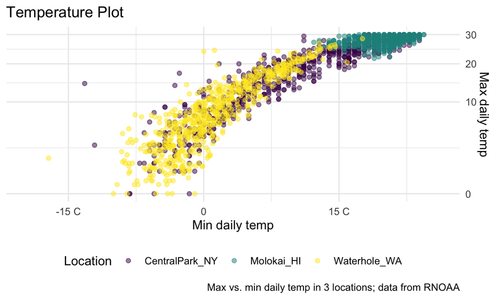

```r
weather_df |>
  ggplot(aes(x = tmin, y = tmax, color = name)) +
  geom_point(alpha = .5) +
  labs(
    title = "Temperature Plot",
    x = "Min daily temp",
    y = "Max daily temp",
    color = "Location",
    caption = "Max vs. min daily temp in 3 locations; data from RNOAA"
  ) +
  scale_x_continuous(
    breaks = c(-15, 0, 15),
    labels = c("-15 C", "0", "15 C")
    ) +
  scale_y_continuous(
    position = "right",
    trans = "sqrt",
    limits = c(0, 30)
  )
```

Note that `limits` doesn’t automatically update the scale/labeling on the corresponding axis, so might need to separately make adjustments to those after limiting.

# Colors

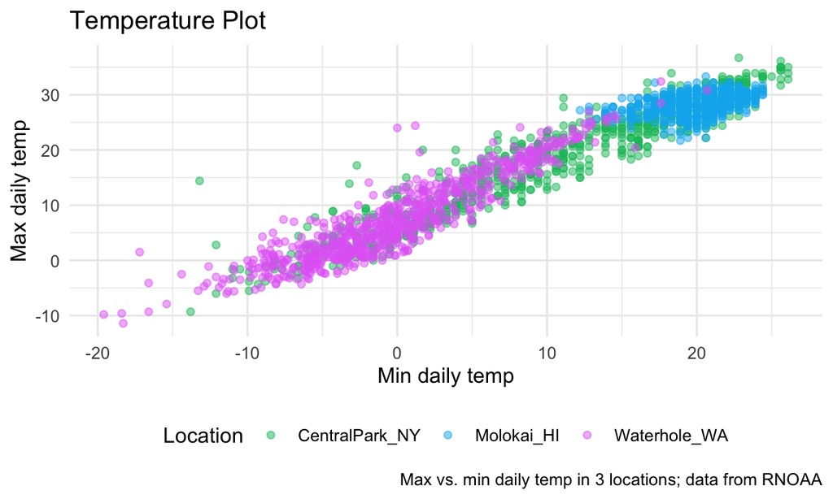

```r
weather_df |>
  ggplot(aes(x = tmin, y = tmax, color = name)) +
  geom_point(alpha = .5) +
  labs(
    title = "Temperature Plot",
    x = "Min daily temp",
    y = "Max daily temp",
    color = "Location",
    caption = "Max vs. min daily temp in 3 locations; data from RNOAA"
  ) +
  scale_color_hue(h = c(150, 300))
```

Other option: viridis::scale_color_viridis(discrete = TRUE). The color schemes from the viridis package are better for color-blindness accessibility and clearer when printing in gray-scale. But, do need to specify discrete vs. continuous with functions from this package.

# Themes

Used, for example, to move the location of the legend.

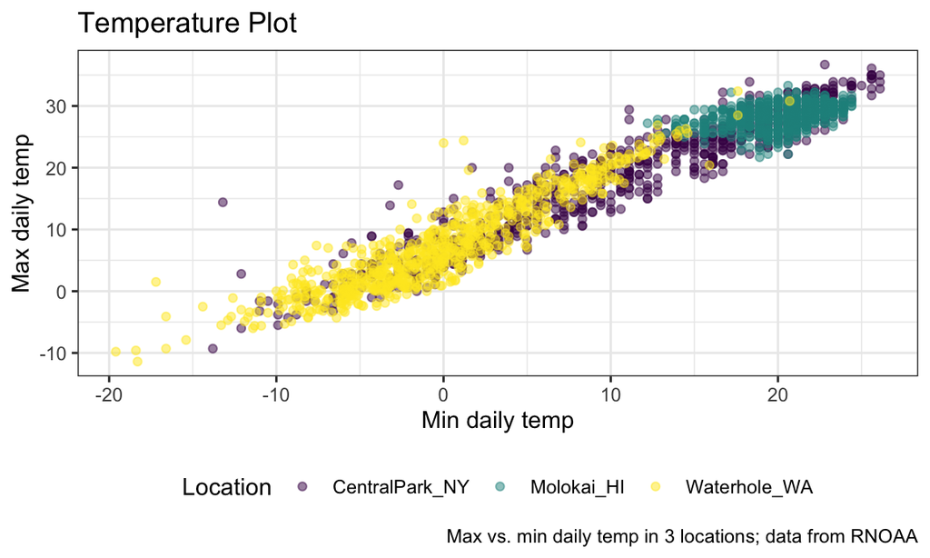

```r
weather_df |>
  ggplot(aes(x = tmin, y = tmax, color = name)) +
  geom_point(alpha = .5) +
  labs(
    title = "Temperature Plot",
    x = "Min daily temp",
    y = "Max daily temp",
    color = "Location",
    caption = "Max vs. min daily temp in 3 locations; data from RNOAA"
  ) +
  viridis::scale_color_viridis(discrete = TRUE) +
  theme_bw() +
  theme(legend.position = "bottom")
```

theme_minimal() is another theme available.

# Data Argument

Allows us to plot separate dataframes on top of one another. This can be useful when want to apply really different formatting to separate datasets within one plot.

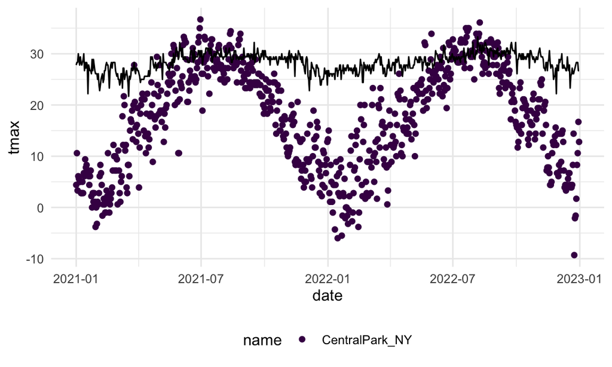

```r
ny_weather_df =
  weather_df |>
  filter(name == "CentralPark_NY")

hawaii_weather_df =
  weather_df |>
  filter(name == "Molokai_HI")

ggplot(ny_weather_df, aes(x = date, y = tmax)) +
  geom_point(aes(color = name)) +
  geom_line(data = hawaii_weather_df)
```

# `patchwork`

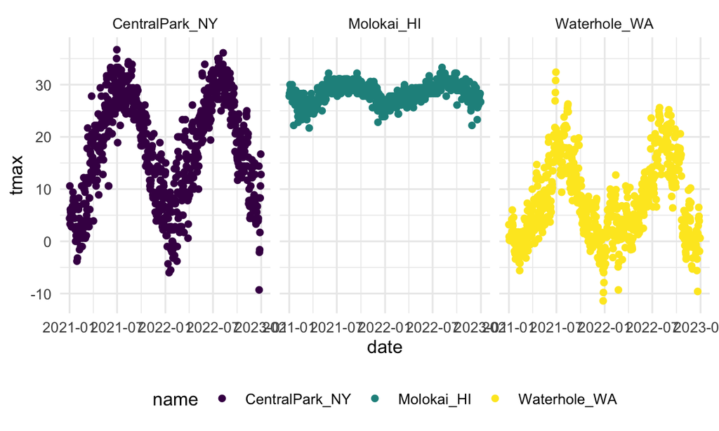

```r
weather_df |>
  ggplot(aes(x = date, y = tmax, color = name)) +
  geom_point() +
  facet_grid(. ~ name)
```

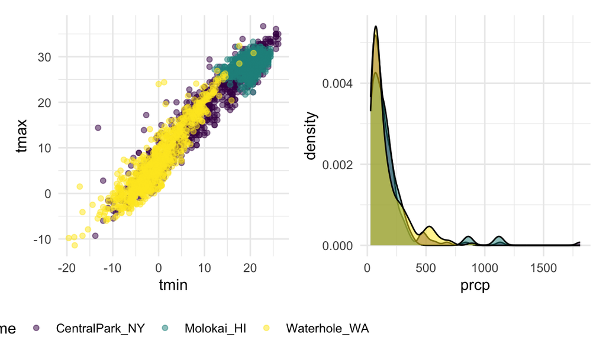

```r
ggp_temp_scatter =
  weather_df |>
  ggplot(aes(x = tmin, y = tmax, color = name)) +
  geom_point(alpha = .5)

ggp_prcp_density =
  weather_df |>
  filter(prcp > 25) |>
  ggplot(aes(x = prcp, fill = name)) +
  geom_density(alpha = .5) +
  theme(legend.position = "none")

ggp_tmax_date =
  weather_df |>
  ggplot(aes(x = date, y = tmax, color = name)) +
  geom_point() +
  geom_smooth(se = FALSE) +
  theme(legend.position = "bottom")

ggp_temp_scatter + ggp_prcp_density
```

# Data Manipulation

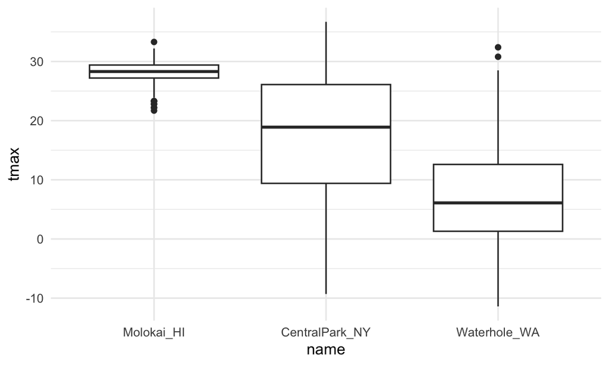

```r
weather_df |>
  mutate(
    name = fct_relevel(name, c("Molokai_HI", "CentralPark_NY", "Waterhole_WA"))
  ) |>
  ggplot(aes(x = name, y = tmax)) +
  geom_boxplot()
```